# lab3

Karen Gong

Partner: Harrison Robel

PHYS 434 AA Lab 3

```python
%matplotlib inline
import numpy as np
import matplotlib
import matplotlib.pyplot as plt
import scipy
from scipy import stats
import plotly.graph_objects as go

#this sets the size of the plot to something useful
plt.rcParams["figure.figsize"] = (20,15)
```

Problem 1

In this example, we are looking at temperature reading, or meta-data, associated with an experiment. For the experiment to work correctly, the temperature should be around 12 K, within 0.4 degree precision of the thermometry and thermal control system. Sometimes, though, the thermal control system recorded a temperature that was no close to 12K and other glitches in the thermometry gave unnaturally high and low readings. In this problem, the goal is to identify and remove all the data collected when the thermal control system was not working.

```
Real data minimum: 10.282406379753038
Real data maximum 13.670148409582154
```

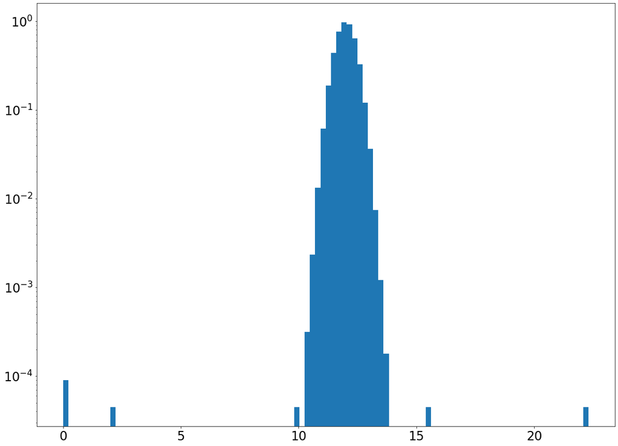

```python
d = np.append(stats.norm.rvs(loc = 12., scale = 0.4, size = 100000), [10., 10.3, 2.1, 0., 0., 15.6, 22.3, 12.7])

# distribution without bad data
rd = stats.norm.rvs(loc = 12., scale = 0.4, size = 100000)
rdmin = (np.min(rd))
rdmax = (np.max(rd))
print("Real data minimum:",rdmin, "\nReal data maximum", rdmax)

fig, ax = plt.subplots(1, 1)
ax.hist(d,100, density=True)
plt.tick_params(labelsize = 24)
plt.yscale('log')
#x = np.linspace(4.95,5.05,1000)
#ax.plot(x,stats.norm.pdf(x,loc = 5., scale = 0.01),linewidth = 8,alpha = 0.7)
plt.show()
```

A) The goal is to identify the bad data and remove it. State the statistical question in words and in math. Apply the statistical test and construct a truth table.

```
Remaining data minimum 11.200062047485936
Remaning data maximum: 12.799946702830635
# of good data in lower range 2322
# of good data in upper range 2206
Total counts left in data set 95472
```

[figure not shown]

```python
# this function removes the outliers from the dataset
# takes in 2 parameters: dataset(data) and the width of the threshold (m)
# 12 is the mean and 0.4 is the standard deviation we are measuring
def reject_outliers(data, m):
    return data[abs(data - 12) < m * 0.4]

# upper proability, 12.4 to +infinity
#upperprob = stats.norm.cdf(12.4, loc = mu, scale = sigma)
#print("upper prob:",upperprob)

# lower probability, -infinity to 11.6
#lowerprob = stats.norm.cdf(11.6, loc = mu, scale = sigma)
#print("lower prob:",lowerprob)

# value to adjust width of threshold is, this value is multiplied by standard deviation
# to determine how wide the threshold is
m = 2

remove = reject_outliers(d, m)

rmmin = np.min(remove)
rmmax = np.max(remove)
print("Remaining data minimum", rmmin, "\nRemaning data maximum:", rmmax)

# count how many values between the minimums/maximums
mini = np.size(np.where((d > rdmin) & (d < rmmin)))
maxi = np.size(np.where((d > rmmax) & (d < rdmax)))
print("# of good data in lower range", mini, "\n# of good data in upper range", maxi)

# how much is left in the array (to see how much you cut off)
totcount = len(remove)
print("Total counts left in data set", totcount)

fig, ax = plt.subplots(1, 1)
ax.hist(remove,100, density=True)
plt.tick_params(labelsize = 24)
plt.ylabel('Temperature (K)', size = 24)
plt.xlabel('Probability (log)', size = 24)
plt.yscale('log')
```

```python
fig = go.Figure(data=[go.Table(header=dict(values=['','True T', 'Bad T']),
                 cells=dict(values=[['Your Test Good', 'Your Test Bad'], [totcount - 1, mini + maxi], [1, 7]]))
                     ])
fig.show()
```

[interactive chart not shown]

The truth table shows how accurate the statistical test we performed was. The number of good and bad values measured depend on the threshold of the data we are measuring. In this case, it was calculated within two standard deviations of the mean.

B) How does the number of omissions, where you threw out good data, depend on the statistical threshold you chose and is it a predictable quantity?

If the statistical threshold chosen is larger, there will be less good data thrown out (omissions) and if the threshold is smaller, there would be more omissions. It's a predictable quantity because the two variables are inversely proportional, so as the threshold gets larger, we can predict that the number of ommissions is lower, and vice versa.

C) Are there mistakes of commission (bad data getting in)? If yes, are they avoidable and how do they depend on your statistical threshold?

Yes, there are definitely mistakes of commission, where bad data is getting in. To avoid letting any bad data in, we can decrease the statistical threshold, thus eliminating the crux of the data we don't want; however, there is the problem that decreasing the threshold may also throw out much of the good data, as well.

Problem 2

In this problem, we are looking for asteroids and the resulting 2D Gaussian distribution of the alignment of stars on subsequent images (shown below). The background measures the movement of stars in arcseconds in the x and y direction. If there is a potential asteroid, there is a signal produced greater than the background. To be considered to have true movement, the asteroid must have a 5-sigma detection probability. To do so, we will utilize the Rayleigh distribution.

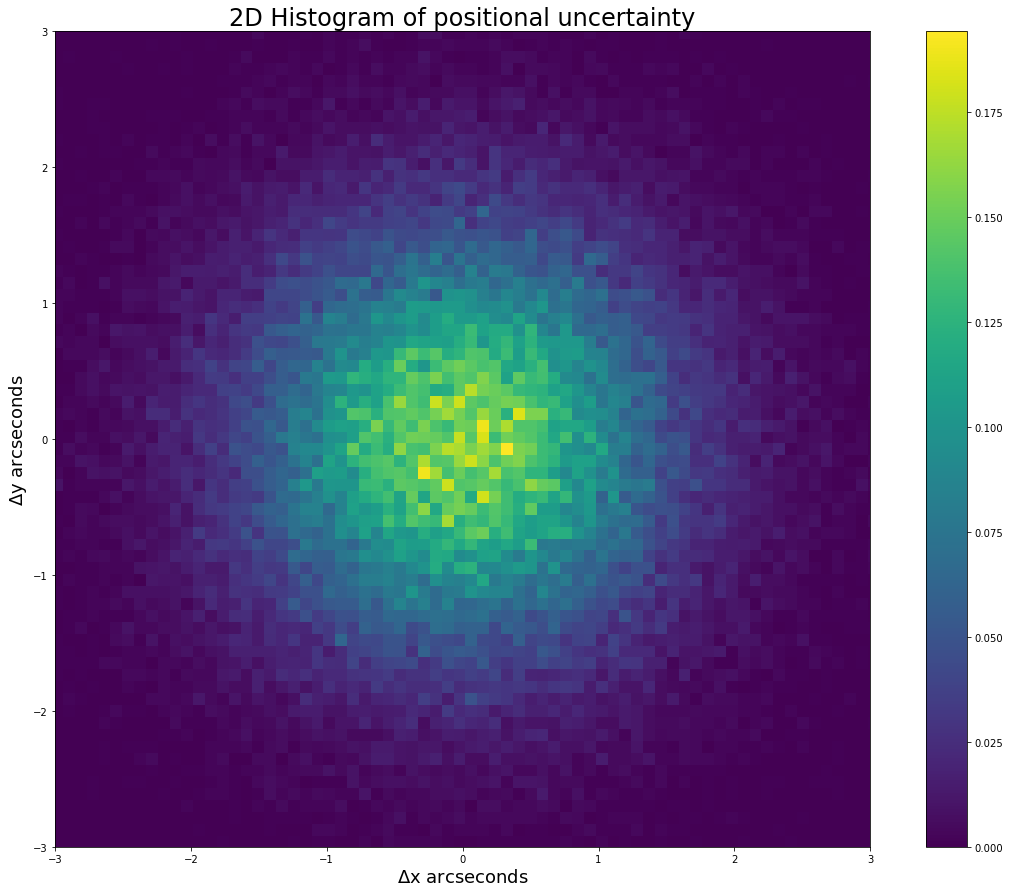

```python
a = np.vstack((stats.norm.rvs( scale = 1, size = 100000), stats.norm.rvs( scale = 1, size = 100000)))
a.shape
fig, ax = plt.subplots(1, 1)
h = ax.hist2d(a[0,:],a[1,:],bins=100, density=True);
ax.set_aspect('equal', 'box')
plt.xlim([-3 , 3])
plt.ylim([-3 , 3])
plt.title("2D Histogram of positional uncertainty", fontsize = 24)
plt.ylabel("$\Delta$y arcseconds", fontsize = 18)
plt.xlabel("$\Delta$x arcseconds", fontsize = 18)
plt.colorbar(h[3], ax=ax)
```

1. Statistical Question:

How far does an asteroid have to move (in arcseconds) between images to be considered a 5-sigma detction of true movement?

1. Mathematical Statement (including an analytic description of the pdf):

In this problem, we can utilize the Rayleigh distribution to measure the distance, in arcseconds, a potential asteroid's signal produces. A 2D Gaussian distribution can be represented in a Rayleigh distribution if the two distributions are independent, just like this case. It is represented by $\mbox{R = }\sqrt{X^2 + Y^2} $.

To find the probability associated with a 5-sigma detection, we can look it up or calculate it using the normal cdf() function. Then using that probability, we can then find the distance in arcseconds (using inverse cdf ppf() of a Rayleigh distribution) that must be traveled by a potential asteroid in order to be considered significant.

$\mbox{prob5sigma = norm.cdf(x)}$

$\mbox{Distance = rayleigh.ppf(prob5sigma)}$

1. Find distance in arcseconds that represents 5 sigma detection of motion.

```python
#prob5sig = 1/3.5e6
prob5sig = stats.norm.cdf(5)

sigma = stats.rayleigh.ppf(prob5sig)
print("The distance in arcseconds that represents 5sigma detection of motion:", sigma)
```

```
The distance in arcseconds that represents 5sigma detection of motion: 5.489079776034238
```

To be confident that it's a meteor, it needs to move more than 5.5 arcseconds. This makes sense because the potential asteroid needs to move quite a significant amount to be considered an actual asteroid, otherwise, we could attribute the signal to atmospheric or instrumental effects.

Problem 3

In this problem, we are observing cosmic rays in moon sized patches in the sky. One of the key backgrounds for gamma-ray telescopes are cosmic rays, but because the cosmic rays are high energy particles, they spiral in the magnetic field of the galaxy so from the Earth's perspective, they appear from all directions. The direction the cosmic ray is travelling when it reaches the Earth tells us nothing about where it came from. However, at extremely high energies (trillion electron volt energies and above) the spiral loops are fairly large which allows the sun and moon to block the cosmis rays so the sun and moon appear as holes in the cosmic ray sky and the rays from those directions are absorbed.

In this problem, we'll assume that in a moon sized patch on the sky we normally have a cosmic ray rate of 1 cosmic ray per minute, where the arrivals are random. We will observe 8 hours per night for 15 days to see the effect of the moon's shadow on the detection of cosmic and gamma-rays.

1. Statistical Question:

If we can observe the moon for 15 days, 8 hours each night, and see 6800 cosmic rays, what is the significance of the moon's shadow on detecting cosmic and gamma-rays?

1. Mathematical Expression (describe both the expected background pdf() and the integral):

The cosmic ray background will follow a Poisson distribution, since the value for the counts is a discrete value. Also, since the time interval is a large value, there could be the look-elsewhere effect which has the corresponding large trials factor. To find the pdf over 15 days, we will find the total time we spend observing the sky in minutes.

$\mbox{Prob = } \int_{1}^{\infty} \sum \mbox{Pois(}\lambda_i\mbox{)}$

1. Convert to sigma

Determine the probability and convert it to sigma to determine the significance.

```python
time = 15 * 8 * 60
mu = 1 # average background rate
counts = 6800
avgcounts = counts / time

k = np.arange(1,time)

# distribution
r = stats.poisson.rvs(mu, loc = avgcounts, size = mu * time)
d = stats.poisson.pmf(r, mu)
#print(d)

#probability of distribution
dist = np.sum(d) / len(d)
prob = stats.poisson.cdf(dist, mu)

# sigma of distribution
sigma = stats.norm.ppf(prob)
print(sigma)
```

[output not shown]

The sigma value is very small so the significance of the shadow cast by the moon is minute. It may seem more obvious that the count number may be due to random chance as the time value increases to the hundred thousands and on.